# Separation stats

Sasha and Flavia

# Plot data

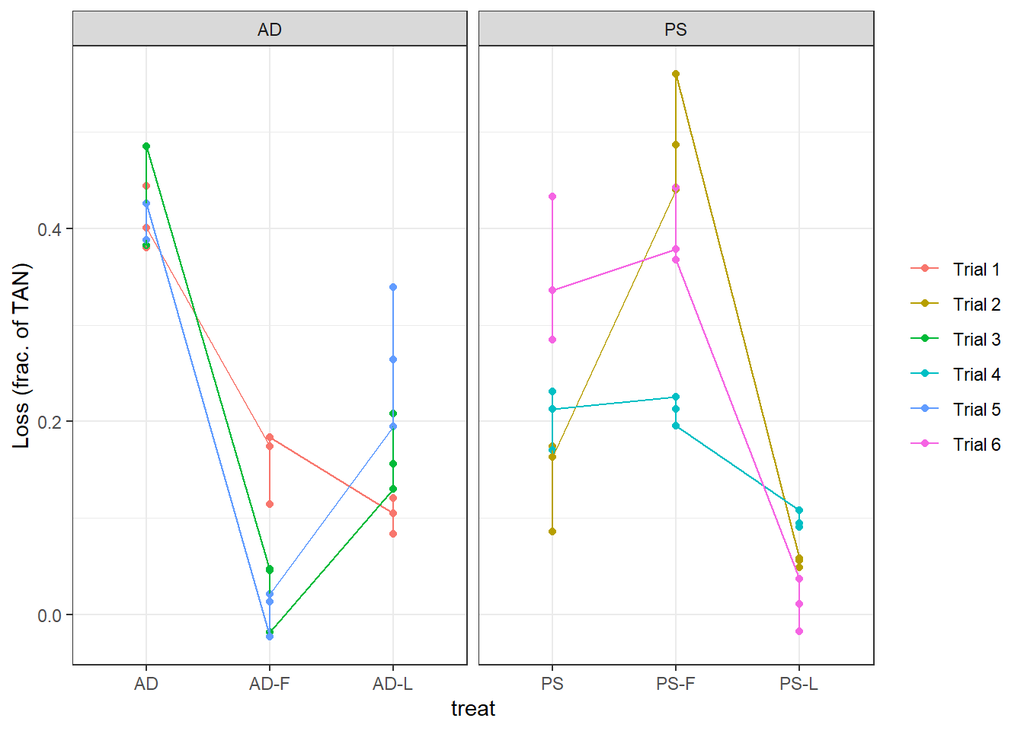

```r
ggplot(statsumm, aes(treat, e.rel.130, color = trial)) +
  geom_point() +
  geom_line(aes(group = trial)) +
  facet_wrap(~ slurry.type, scales = 'free_x') +
  theme_bw() +
  labs(y = 'Loss (frac. of TAN)') +
  theme(legend.title = element_blank())
```

Through means.

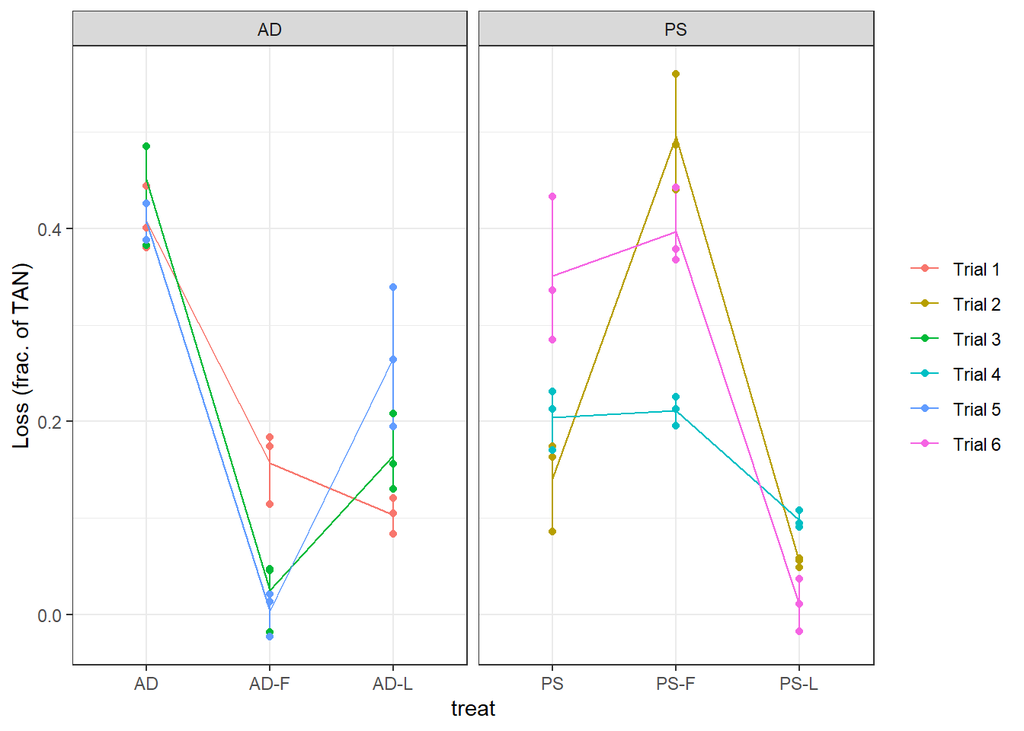

```r
ggplot(statsumm, aes(treat, e.rel.130, color = trial)) +
  geom_line() +
  geom_point() +
  stat_summary(aes(group = trial), fun = mean, geom = 'line') +
  facet_wrap(~ slurry.type, scales = 'free_x') +
  theme_bw() +
  labs(y = 'Loss (frac. of TAN)') +
  theme(legend.title = element_blank())
```

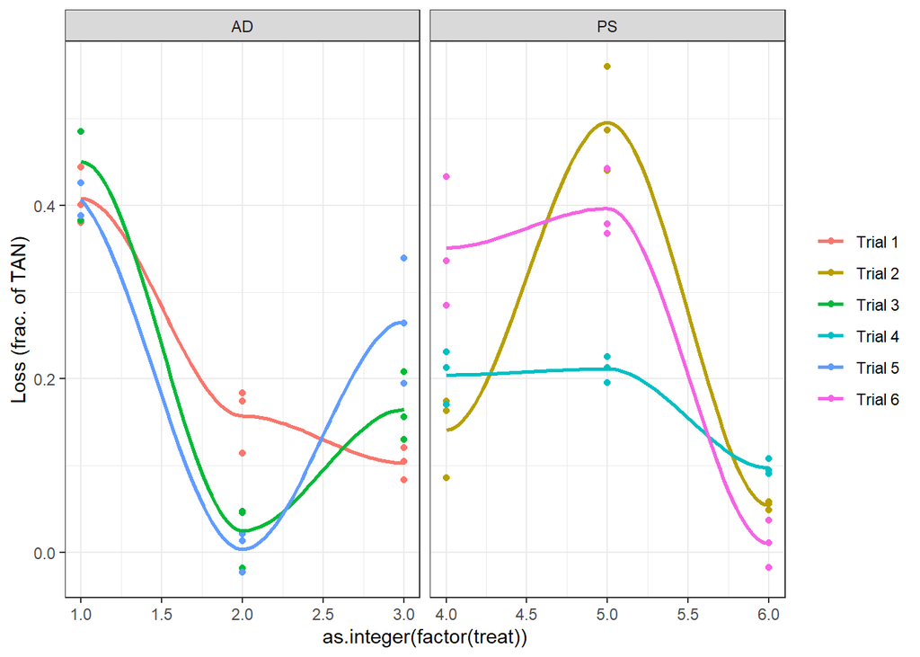

```r
ggplot(statsumm, aes(as.integer(factor(treat)), e.rel.130, color = trial)) +
  geom_point() +
  geom_smooth(se = FALSE) +
  facet_wrap(~ slurry.type, scales = 'free_x') +
  theme_bw() +
  labs(y = 'Loss (frac. of TAN)') +
  theme(legend.title = element_blank())
```

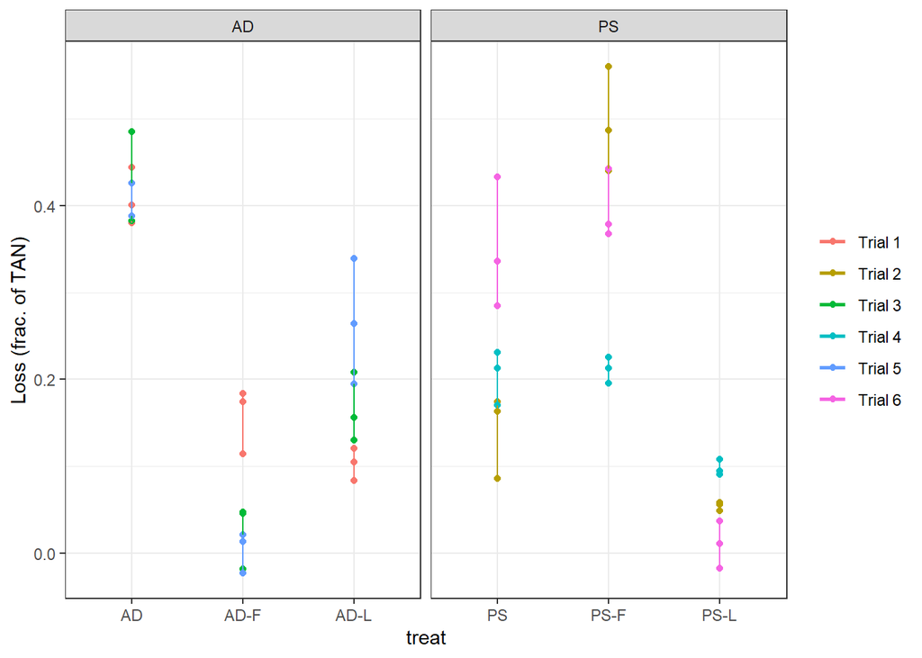

```r
ggplot(statsumm, aes(treat, e.rel.130, color = trial)) +
  geom_point() +
  geom_line() +
  geom_smooth(se = FALSE) +
  facet_wrap(~ slurry.type, scales = 'free_x') +
  theme_bw() +
  labs(y = 'Loss (frac. of TAN)') +
  theme(legend.title = element_blank())
```

# Mixed-effects models

## Model 1

First ignore any variation in separation response among trials (plot shows evidence that we should *not* ignore it).

```r
mod1 <- lmer(e.rel.130 ~ separation * slurry.type + (1|trial), data = statsumm, REML = FALSE)
```

```
## boundary (singular) fit: see help('isSingular')
```

```r
summary(mod1)
```

```
## Linear mixed model fit by maximum likelihood  ['lmerMod']
## Formula: e.rel.130 ~ separation * slurry.type + (1 | trial)
##    Data: statsumm
##
##      AIC      BIC   logLik deviance df.resid
##    -99.2    -83.4     57.6   -115.2       45
##
## Scaled residuals:
##     Min      1Q  Median      3Q     Max
## -2.1076 -0.5992 -0.0659  0.6449  2.4584
##
## Random effects:
##  Groups   Name        Variance  Std.Dev.
##  trial    (Intercept) 9.191e-23 9.587e-12
##  Residual             6.660e-03 8.161e-02
## Number of obs: 53, groups:  trial, 6
##
## Fixed effects:
##                                Estimate Std. Error t value
## (Intercept)                     0.42400    0.02885  14.695
## separationLiquid               -0.24602    0.03966  -6.204
## separationSolid                -0.36210    0.03966  -9.131
## slurry.typePS                  -0.19163    0.03966  -4.832
## separationLiquid:slurry.typePS  0.06763    0.05525   1.224
## separationSolid:slurry.typePS   0.49773    0.05525   9.009
##
## Correlation of Fixed Effects:
##             (Intr) sprtnL sprtnS slr.PS sL:.PS
## separatnLqd -0.728
## separatnSld -0.728  0.529
## slrry.typPS -0.728  0.529  0.529
## sprtnLq:.PS  0.522 -0.718 -0.380 -0.718
## sprtnSl:.PS  0.522 -0.380 -0.718 -0.718  0.515
## optimizer (nloptwrap) convergence code: 0 (OK)
## boundary (singular) fit: see help('isSingular')
```

```r
anova(mod1)
```

|  | npar | Sum Sq | Mean Sq | F value |
| --- | --- | --- | --- | --- |
| separation | 2 | 3.730873e-01 | 1.865437e-01 | 2.800882e+01 |
| slurry.type | 1 | 4.628053e-06 | 4.628053e-06 | 6.948845e-04 |
| separation:slurry.type | 2 | 6.463589e-01 | 3.231795e-01 | 4.852417e+01 |

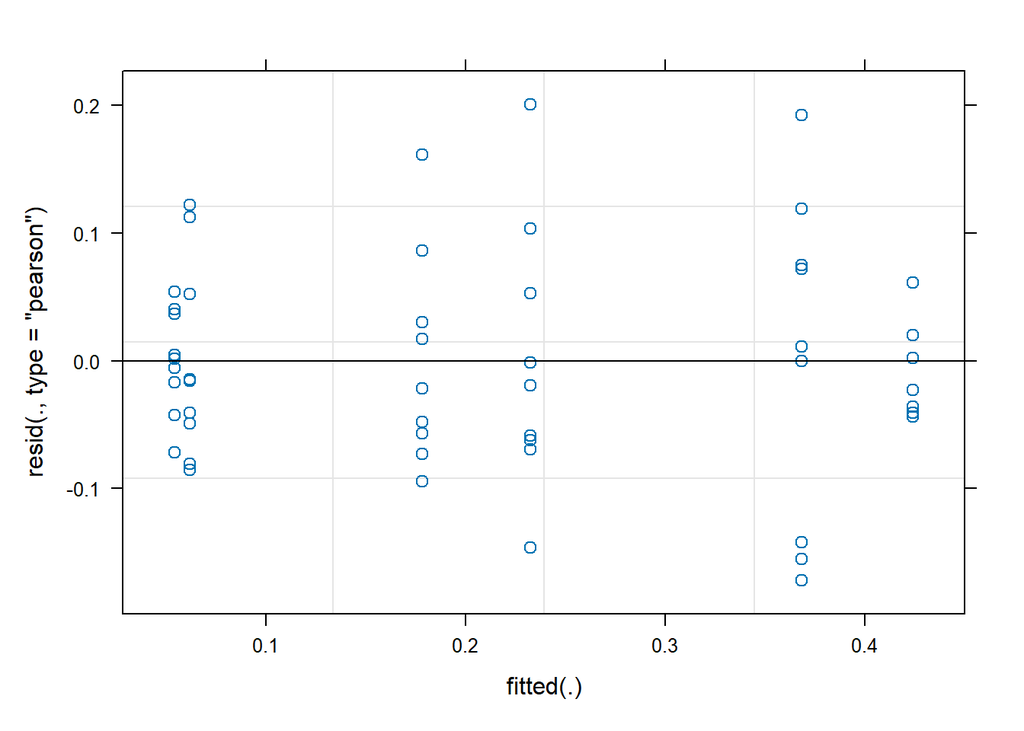

```r
plot(mod1)
```

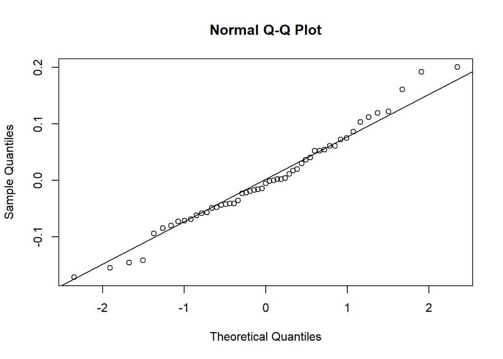

```r
qqnorm(resid(mod1))
qqline(resid(mod1))
```

## Model 2

Now include this random separation effect across trials.

```r
mod2 <- lmer(e.rel.130 ~ separation * slurry.type + (1 + separation | trial), data = statsumm, REML = FALSE)
summary(mod2)
```

```
## Linear mixed model fit by maximum likelihood  ['lmerMod']
## Formula: e.rel.130 ~ separation * slurry.type + (1 + separation | trial)
##    Data: statsumm
##
##      AIC      BIC   logLik deviance df.resid
##   -128.2   -102.6     77.1   -154.2       40
##
## Scaled residuals:
##      Min       1Q   Median       3Q      Max
## -1.61071 -0.52668 -0.04758  0.57305  2.47481
##
## Random effects:
##  Groups   Name             Variance Std.Dev. Corr
##  trial    (Intercept)      0.003566 0.05972
##           separationLiquid 0.008367 0.09147  -0.88
##           separationSolid  0.013948 0.11810  -0.63  0.22
##  Residual                  0.001752 0.04186
## Number of obs: 53, groups:  trial, 6
##
## Fixed effects:
##                                Estimate Std. Error t value
## (Intercept)                     0.42072    0.03760  11.189
## separationLiquid               -0.24274    0.05665  -4.285
## separationSolid                -0.35882    0.07120  -5.040
## slurry.typePS                  -0.18835    0.05289  -3.561
## separationLiquid:slurry.typePS  0.06435    0.07992   0.805
## separationSolid:slurry.typePS   0.49445    0.10054   4.918
##
## Correlation of Fixed Effects:
##             (Intr) sprtnL sprtnS slr.PS sL:.PS
## separatnLqd -0.859
## separatnSld -0.635  0.252
## slrry.typPS -0.711  0.611  0.452
## sprtnLq:.PS  0.609 -0.709 -0.179 -0.859
## sprtnSl:.PS  0.450 -0.178 -0.708 -0.634  0.249
```

```r
anova(mod2)
```

|  | npar | Sum Sq | Mean Sq | F value |
| --- | --- | --- | --- | --- |
| separation | 2 | 0.04946505 | 0.02473252 | 14.113305 |
| slurry.type | 1 | 0.01346821 | 0.01346821 | 7.685463 |
| separation:slurry.type | 2 | 0.04271745 | 0.02135872 | 12.188088 |

```r
mod2
```

```
## Linear mixed model fit by maximum likelihood  ['lmerMod']
## Formula: e.rel.130 ~ separation * slurry.type + (1 + separation | trial)
##    Data: statsumm
##       AIC       BIC    logLik  deviance  df.resid
## -128.1957 -102.5819   77.0979 -154.1957        40
## Random effects:
##  Groups   Name             Std.Dev. Corr
##  trial    (Intercept)      0.05972
##           separationLiquid 0.09147  -0.88
##           separationSolid  0.11810  -0.63  0.22
##  Residual                  0.04186
## Number of obs: 53, groups:  trial, 6
## Fixed Effects:
##                    (Intercept)                separationLiquid                 separationSolid                   slurry.typePS
##                        0.42072                        -0.24274                        -0.35882                        -0.18835
## separationLiquid:slurry.typePS   separationSolid:slurry.typePS
##                        0.06435                         0.49445
```

## Model 2 hypothsis tests

We can determine if there is evidence for the separation in trial effect with a likelihood ratio test.

```r
anova(mod1, mod2, test = 'Chisq')
```

|  | npar | AIC | BIC | logLik | deviance | Chisq | Df | Pr(>Chisq) |
| --- | --- | --- | --- | --- | --- | --- | --- | --- |
| mod1 | 8 | -99.20781 | -83.44548 | 57.60391 | -115.2078 | NA | NA | NA |
| mod2 | 13 | -128.19573 | -102.58194 | 77.09787 | -154.1957 | 38.98792 | 5 | 2.388172e-07 |

Strong evidence, with p value below 1E-6.

For interaction term:

```r
mod2b <- lmer(e.rel.130 ~ separation + slurry.type + (1 + separation | trial), data = statsumm, REML = FALSE)
anova(mod2, mod2b, test = 'Chisq')
```

|  | npar | AIC | BIC | logLik | deviance | Chisq | Df | Pr(>Chisq) |
| --- | --- | --- | --- | --- | --- | --- | --- | --- |
| mod2b | 11 | -122.4525 | -100.7793 | 72.22627 | -144.4525 | NA | NA | NA |
| mod2 | 13 | -128.1957 | -102.5819 | 77.09787 | -154.1957 | 9.7432 | 2 | 0.007661097 |

But I’ve realized (remembered?) we can just use `drop1()` without creating the other model explicitly.

```r
drop1(mod2, test = 'Chisq')
```

|  | npar | AIC | LRT | Pr(Chi) |
| --- | --- | --- | --- | --- |
|  | NA | -128.1957 | NA | NA |
| separation:slurry.type | 2 | -122.4525 | 9.7432 | 0.007661097 |

p < 0.01, pretty clear.

And it is clear from the plots that there is no consistent difference between:

- solid and liquid fractions from AD,
- raw and solid from pig slurry.

The only thing not clear from the combination of these results and the plots is if:

- AD liquid fraction is in fact lower than raw AD,
- pig liquid fraction is in fact lower than raw pig slurry.

We can test exactly these and only these by grouping factor levels and using likelihood ratio tests. The `psg` is for “pig slurry **g**rouped”.

```r
statsumm[, separation.psg := separation]
statsumm[slurry.type == 'PS' & separation == 'Liquid', separation.psg := 'Unsep']
table(statsumm[, .(slurry.type, separation, trial)])
```

```
## , , trial = Trial 1
##
##            separation
## slurry.type Unsep Liquid Solid
##          AD     3      3     3
##          PS     0      0     0
##
## , , trial = Trial 2
##
##            separation
## slurry.type Unsep Liquid Solid
##          AD     0      0     0
##          PS     3      3     3
##
## , , trial = Trial 3
##
##            separation
## slurry.type Unsep Liquid Solid
##          AD     3      3     3
##          PS     0      0     0
##
## , , trial = Trial 4
##
##            separation
## slurry.type Unsep Liquid Solid
##          AD     0      0     0
##          PS     3      3     3
##
## , , trial = Trial 5
##
##            separation
## slurry.type Unsep Liquid Solid
##          AD     2      3     3
##          PS     0      0     0
##
## , , trial = Trial 6
##
##            separation
## slurry.type Unsep Liquid Solid
##          AD     0      0     0
##          PS     3      3     3
```

```r
table(statsumm[, .(slurry.type, separation.psg, trial)])
```

```
## , , trial = Trial 1
##
##            separation.psg
## slurry.type Unsep Liquid Solid
##          AD     3      3     3
##          PS     0      0     0
##
## , , trial = Trial 2
##
##            separation.psg
## slurry.type Unsep Liquid Solid
##          AD     0      0     0
##          PS     6      0     3
##
## , , trial = Trial 3
##
##            separation.psg
## slurry.type Unsep Liquid Solid
##          AD     3      3     3
##          PS     0      0     0
##
## , , trial = Trial 4
##
##            separation.psg
## slurry.type Unsep Liquid Solid
##          AD     0      0     0
##          PS     6      0     3
##
## , , trial = Trial 5
##
##            separation.psg
## slurry.type Unsep Liquid Solid
##          AD     2      3     3
##          PS     0      0     0
##
## , , trial = Trial 6
##
##            separation.psg
## slurry.type Unsep Liquid Solid
##          AD     0      0     0
##          PS     6      0     3
```

And here is “anaerobic digestion **g**rouped”.

```r
statsumm[, separation.adg := separation]
statsumm[slurry.type == 'AD' & separation == 'Liquid', separation.adg := 'Unsep']
table(statsumm[, .(slurry.type, separation, trial)])
```

```
## , , trial = Trial 1
##
##            separation
## slurry.type Unsep Liquid Solid
##          AD     3      3     3
##          PS     0      0     0
##
## , , trial = Trial 2
##
##            separation
## slurry.type Unsep Liquid Solid
##          AD     0      0     0
##          PS     3      3     3
##
## , , trial = Trial 3
##
##            separation
## slurry.type Unsep Liquid Solid
##          AD     3      3     3
##          PS     0      0     0
##
## , , trial = Trial 4
##
##            separation
## slurry.type Unsep Liquid Solid
##          AD     0      0     0
##          PS     3      3     3
##
## , , trial = Trial 5
##
##            separation
## slurry.type Unsep Liquid Solid
##          AD     2      3     3
##          PS     0      0     0
##
## , , trial = Trial 6
##
##            separation
## slurry.type Unsep Liquid Solid
##          AD     0      0     0
##          PS     3      3     3
```

```r
table(statsumm[, .(slurry.type, separation.adg, trial)])
```

```
## , , trial = Trial 1
##
##            separation.adg
## slurry.type Unsep Liquid Solid
##          AD     6      0     3
##          PS     0      0     0
##
## , , trial = Trial 2
##
##            separation.adg
## slurry.type Unsep Liquid Solid
##          AD     0      0     0
##          PS     3      3     3
##
## , , trial = Trial 3
##
##            separation.adg
## slurry.type Unsep Liquid Solid
##          AD     6      0     3
##          PS     0      0     0
##
## , , trial = Trial 4
##
##            separation.adg
## slurry.type Unsep Liquid Solid
##          AD     0      0     0
##          PS     3      3     3
##
## , , trial = Trial 5
##
##            separation.adg
## slurry.type Unsep Liquid Solid
##          AD     5      0     3
##          PS     0      0     0
##
## , , trial = Trial 6
##
##            separation.adg
## slurry.type Unsep Liquid Solid
##          AD     0      0     0
##          PS     3      3     3
```

```r
mod2c <- lmer(e.rel.130 ~ separation.psg + slurry.type + (1 + separation.psg | trial), data = statsumm, REML = FALSE)
```

```
## boundary (singular) fit: see help('isSingular')
```

```r
mod2d <- lmer(e.rel.130 ~ separation.adg + slurry.type + (1 + separation.adg | trial), data = statsumm, REML = FALSE)
```

```
## boundary (singular) fit: see help('isSingular')
```

```r
anova(mod2, mod2c, test = 'Chisq')
```

|  | npar | AIC | BIC | logLik | deviance | Chisq | Df | Pr(>Chisq) |
| --- | --- | --- | --- | --- | --- | --- | --- | --- |
| mod2c | 11 | -74.46412 | -52.7909 | 48.23206 | -96.46412 | NA | NA | NA |
| mod2 | 13 | -128.19573 | -102.5819 | 77.09787 | -154.19573 | 57.73162 | 2 | 2.908967e-13 |

```r
anova(mod2, mod2d, test = 'Chisq')
```

|  | npar | AIC | BIC | logLik | deviance | Chisq | Df | Pr(>Chisq) |
| --- | --- | --- | --- | --- | --- | --- | --- | --- |
| mod2d | 11 | -63.00271 | -41.3295 | 42.50135 | -85.00271 | NA | NA | NA |
| mod2 | 13 | -128.19573 | -102.5819 | 77.09787 | -154.19573 | 69.19303 | 2 | 9.438989e-16 |

Singular fit is problematic (but not fatal) for comparison.

```r
mod1c <- lmer(e.rel.130 ~ separation.psg + slurry.type + (1 | trial), data = statsumm, REML = FALSE)
```

```
## boundary (singular) fit: see help('isSingular')
```

```r
mod1d <- lmer(e.rel.130 ~ separation.adg + slurry.type + (1 | trial), data = statsumm, REML = FALSE)
```

```
## boundary (singular) fit: see help('isSingular')
```

```r
anova(mod1, mod1c, test = 'Chisq')
```

|  | npar | AIC | BIC | logLik | deviance | Chisq | Df | Pr(>Chisq) |
| --- | --- | --- | --- | --- | --- | --- | --- | --- |
| mod1c | 6 | -32.05507 | -20.23332 | 22.02754 | -44.05507 | NA | NA | NA |
| mod1 | 8 | -99.20781 | -83.44548 | 57.60391 | -115.20781 | 71.15274 | 2 | 3.543057e-16 |

```r
anova(mod1, mod1d, test = 'Chisq')
```

|  | npar | AIC | BIC | logLik | deviance | Chisq | Df | Pr(>Chisq) |
| --- | --- | --- | --- | --- | --- | --- | --- | --- |
| mod1d | 6 | -50.53016 | -38.70840 | 31.26508 | -62.53016 | NA | NA | NA |
| mod1 | 8 | -99.20781 | -83.44548 | 57.60391 | -115.20781 | 52.67766 | 2 | 3.640758e-12 |

No better. Try subset instead.

```r
statsummul <- statsumm[separation %in% c('Unsep', 'Liquid')]
```

```r
mod3 <- lmer(e.rel.130 ~ separation * slurry.type + (1|trial), data = statsummul, REML = FALSE)
summary(mod3)
```

```
## Linear mixed model fit by maximum likelihood  ['lmerMod']
## Formula: e.rel.130 ~ separation * slurry.type + (1 | trial)
##    Data: statsummul
##
##      AIC      BIC   logLik deviance df.resid
##    -76.2    -66.9     44.1    -88.2       29
##
## Scaled residuals:
##      Min       1Q   Median       3Q      Max
## -1.93254 -0.72912 -0.08245  0.56096  2.81727
##
## Random effects:
##  Groups   Name        Variance  Std.Dev.
##  trial    (Intercept) 0.0005333 0.02309
##  Residual             0.0042928 0.06552
## Number of obs: 35, groups:  trial, 6
##
## Fixed effects:
##                                Estimate Std. Error t value
## (Intercept)                     0.42616    0.02679  15.907
## separationLiquid               -0.24818    0.03189  -7.783
## slurry.typePS                  -0.19380    0.03705  -5.231
## separationLiquid:slurry.typePS  0.06980    0.04439   1.572
##
## Correlation of Fixed Effects:
##             (Intr) sprtnL slr.PS
## separatnLqd -0.632
## slrry.typPS -0.723  0.457
## sprtnLq:.PS  0.454 -0.718 -0.618
```

```r
anova(mod3)
```

|  | npar | Sum Sq | Mean Sq | F value |
| --- | --- | --- | --- | --- |
| separation | 1 | 0.38238814 | 0.38238814 | 89.077466 |
| slurry.type | 1 | 0.12606261 | 0.12606261 | 29.366334 |
| separation:slurry.type | 1 | 0.01061047 | 0.01061047 | 2.471713 |

Check for interaction now.

```r
mod3b <- lmer(e.rel.130 ~ separation + slurry.type + (1|trial), data = statsummul, REML = FALSE)
anova(mod3, mod3b, test = 'Chisq')
```

|  | npar | AIC | BIC | logLik | deviance | Chisq | Df | Pr(>Chisq) |
| --- | --- | --- | --- | --- | --- | --- | --- | --- |
| mod3b | 5 | -75.83521 | -68.05847 | 42.91760 | -85.83521 | NA | NA | NA |
| mod3 | 6 | -76.18513 | -66.85305 | 44.09257 | -88.18513 | 2.349925 | 1 | 0.125289 |

Nope! So solid fraction response drives interaction. That is obvious from the plots.

So we can easily test for overall unsep vs. liquid effect.

```r
mod3c <- lmer(e.rel.130 ~ slurry.type + (1|trial), data = statsummul, REML = FALSE)
```

```
## boundary (singular) fit: see help('isSingular')
```

```r
summary(mod3c)
```

```
## Linear mixed model fit by maximum likelihood  ['lmerMod']
## Formula: e.rel.130 ~ slurry.type + (1 | trial)
##    Data: statsummul
##
##      AIC      BIC   logLik deviance df.resid
##    -36.9    -30.7     22.4    -44.9       31
##
## Scaled residuals:
##     Min      1Q  Median      3Q     Max
## -1.6476 -0.7586 -0.2335  0.7200  2.2744
##
## Random effects:
##  Groups   Name        Variance Std.Dev.
##  trial    (Intercept) 0.00000  0.0000
##  Residual             0.01624  0.1274
## Number of obs: 35, groups:  trial, 6
##
## Fixed effects:
##               Estimate Std. Error t value
## (Intercept)    0.29375    0.03091   9.505
## slurry.typePS -0.15058    0.04310  -3.494
##
## Correlation of Fixed Effects:
##             (Intr)
## slrry.typPS -0.717
## optimizer (nloptwrap) convergence code: 0 (OK)
## boundary (singular) fit: see help('isSingular')
```

```r
anova(mod3c, mod3b, test = 'Chisq')
```

|  | npar | AIC | BIC | logLik | deviance | Chisq | Df | Pr(>Chisq) |
| --- | --- | --- | --- | --- | --- | --- | --- | --- |
| mod3c | 4 | -36.88828 | -30.66689 | 22.44414 | -44.88828 | NA | NA | NA |
| mod3b | 5 | -75.83521 | -68.05847 | 42.91760 | -85.83521 | 40.94692 | 1 | 1.564201e-10 |

```r
drop1(mod3b, test = 'Chisq')
```

```
## boundary (singular) fit: see help('isSingular')
```

|  | npar | AIC | LRT | Pr(Chi) |
| --- | --- | --- | --- | --- |
|  | NA | -75.83521 | NA | NA |
| separation | 1 | -36.88828 | 40.94692 | 1.564201e-10 |
| slurry.type | 1 | -66.95528 | 10.87993 | 9.721213e-04 |

We still have the singular fit issue, but a very clear effect.

# Conclusions:

- Separation affects emission
- The reduction for the solid fraction differs between slurry types
- The liquid fraction has lower emission than whole slurry for both, and the reduction is not clearly different between slurry types
- For digestate, both liquid and solid fractions have lower emission than whole slurry, but are not clearly different from each other, if we consider that the separation effect varies among trials (and it clearly does, from mod2)
- For pig slurry, whole slurry and the solid fraction are not clearly different, but liquid is clearly different (lower) than both

# Biochar stats

Stats for the biochar trials 8 and 9, where we want to test if an increasing dose of biochar to both liquid pig slurry and liquid digestate had an effect on emissions The dose has been considered as a numerical variable 0, 0.02, 0.1 i.e. 0, 2, and 10% of biochar on a wet weight basis. Make the plots of liquid pig slurry and liquid digestate with an increasing biochar dose.

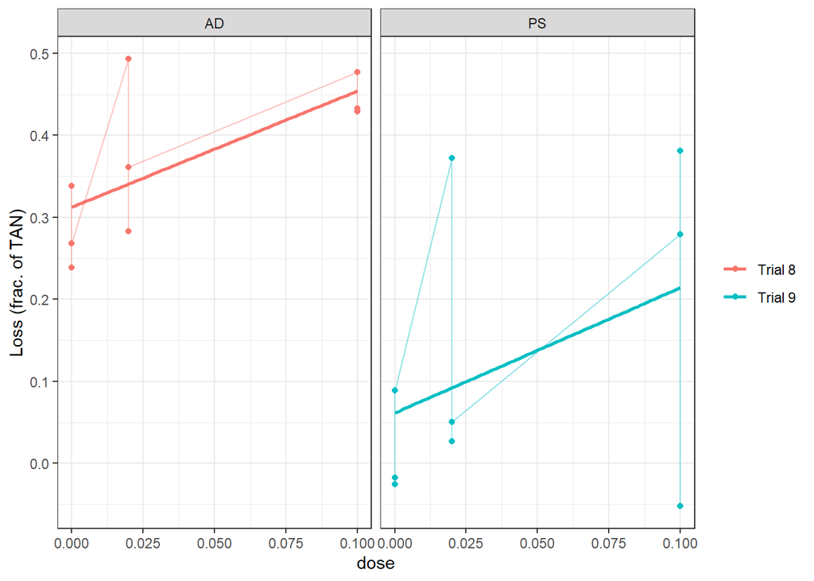

```r
ggplot(bsumm, aes(dose, e.rel.130, color = trial)) +
  geom_point() +
  geom_line(alpha = 0.4) +
  geom_smooth(method = lm, se = FALSE) +
  facet_wrap(~ slurry.type, scales = 'free_x') +
  theme_bw() +
  labs(y = 'Loss (frac. of TAN)') +
  theme(legend.title = element_blank())
```

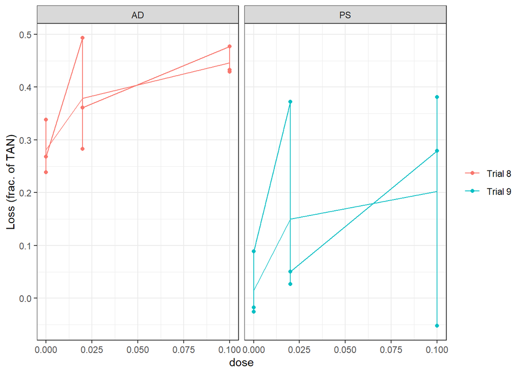

```r
ggplot(bsumm, aes(dose, e.rel.130, color = trial)) +
  geom_line() +
  geom_point() +
  stat_summary(aes(group = trial), fun = mean, geom = 'line') +
  facet_wrap(~ slurry.type, scales = 'free_x') +
  theme_bw() +
  labs(y = 'Loss (frac. of TAN)') +
  theme(legend.title = element_blank())
```

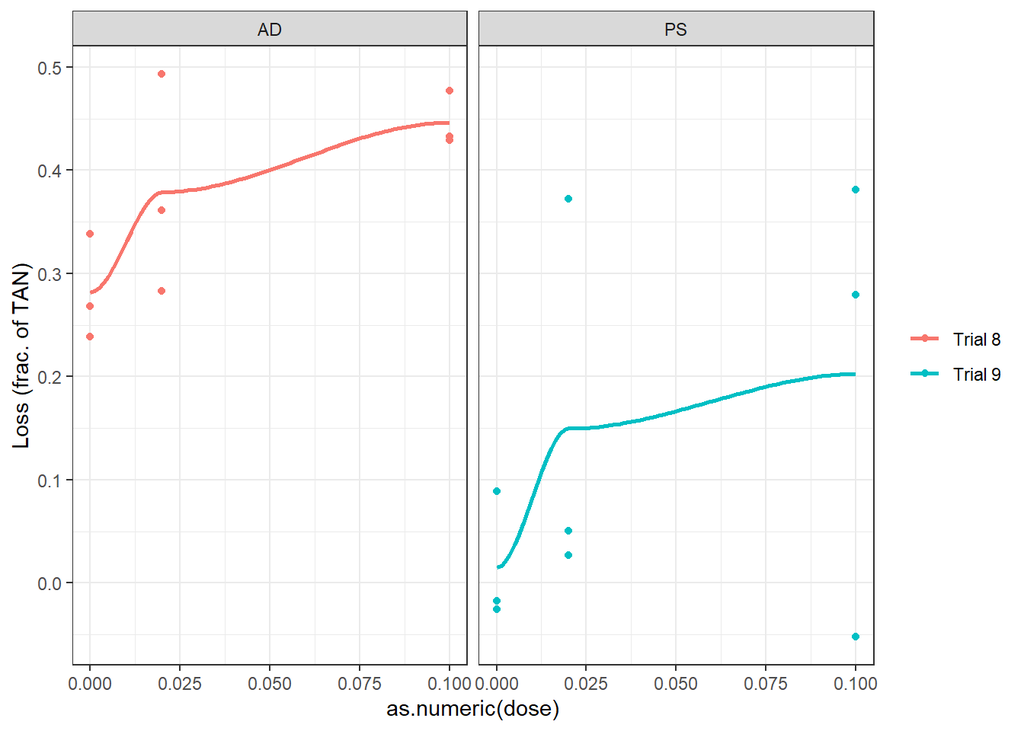

```r
ggplot(bsumm, aes(as.numeric(dose), e.rel.130, color = trial)) +
  geom_point() +
  geom_smooth(se = FALSE) +
  facet_wrap(~ slurry.type, scales = 'free_x') +
  theme_bw() +
  labs(y = 'Loss (frac. of TAN)') +
  theme(legend.title = element_blank())
```

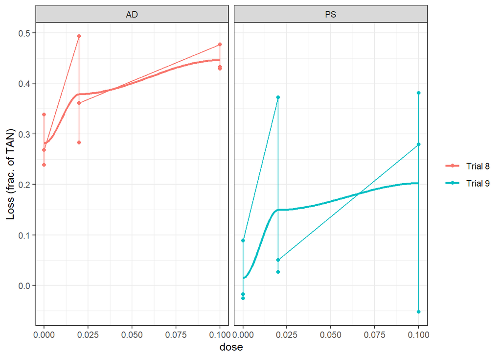

```r
ggplot(bsumm, aes(dose, e.rel.130, color = trial)) +
  geom_point() +
  geom_line() +
  geom_smooth(se = FALSE) +
  facet_wrap(~ slurry.type, scales = 'free_x') +
  theme_bw() +
  labs(y = 'Loss (frac. of TAN)') +
  theme(legend.title = element_blank())
```

Plots show does effect but variability is high.

Linear model to test if the increasing dose of biochar (0, 2, 10 %) added to liquid digestate and liquid pig slurry has an effect on emissions.

```r
modb <- lm(e.rel.130 ~ dose*slurry.type, data = bsumm)
summary(modb)
```

```
##
## Call:
## lm(formula = e.rel.130 ~ dose * slurry.type, data = bsumm)
##
## Residuals:
##      Min       1Q   Median       3Q      Max
## -0.26657 -0.06319 -0.02300  0.02674  0.28007
##
## Coefficients:
##                    Estimate Std. Error t value Pr(>|t|)
## (Intercept)         0.31233    0.05930   5.267 0.000119 ***
## dose                1.41667    1.00720   1.407 0.181374
## slurry.typePS      -0.25093    0.08387  -2.992 0.009703 **
## dose:slurry.typePS  0.11000    1.42440   0.077 0.939537
## ---
## Signif. codes:  0 '***' 0.001 '**' 0.01 '*' 0.05 '.' 0.1 ' ' 1
##
## Residual standard error: 0.1305 on 14 degrees of freedom
## Multiple R-squared:  0.5921, Adjusted R-squared:  0.5047
## F-statistic: 6.775 on 3 and 14 DF,  p-value: 0.00473
```

```r
anova(modb)
```

|  | Df | Sum Sq | Mean Sq | F value | Pr(>F) |
| --- | --- | --- | --- | --- | --- |
| dose | 1 | 0.07277097 | 0.07277097 | 4.269864859 | 0.057812985 |
| slurry.type | 1 | 0.27350408 | 0.27350408 | 16.047957124 | 0.001300682 |
| dose:slurry.type | 1 | 0.00010164 | 0.00010164 | 0.005963766 | 0.939537039 |
| Residuals | 14 | 0.23860091 | 0.01704292 | NA | NA |

Model shows overall slurry type (or trial) effect, and *almost* shows a clear biochar does effect (p > 0.05 but close). No evidence of an interaction.

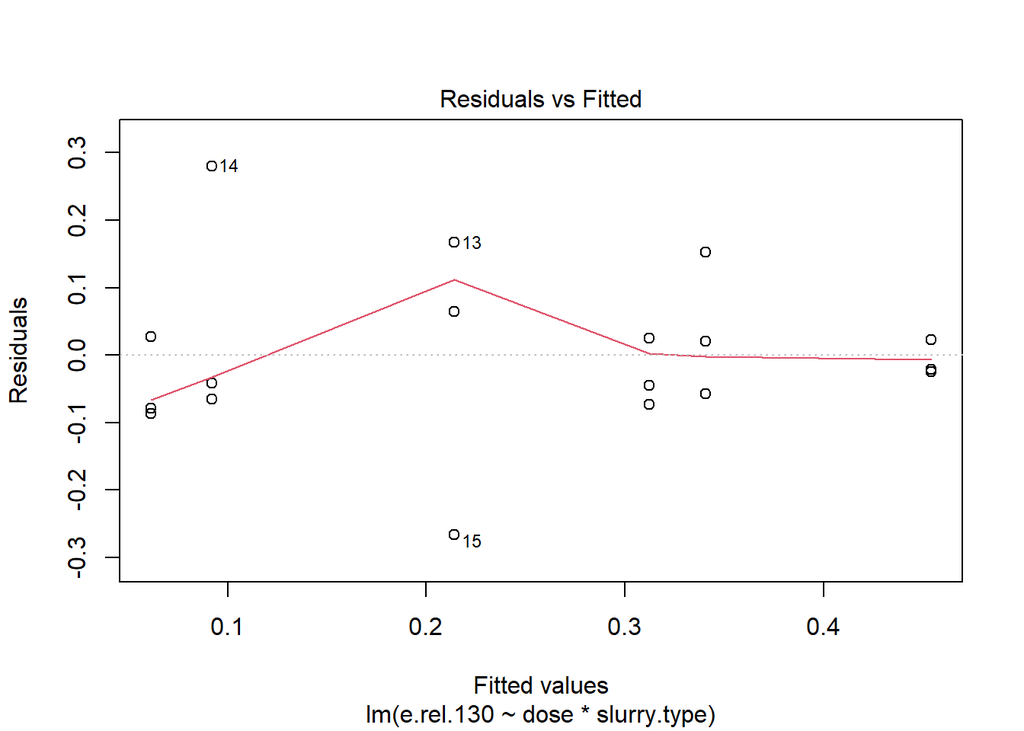

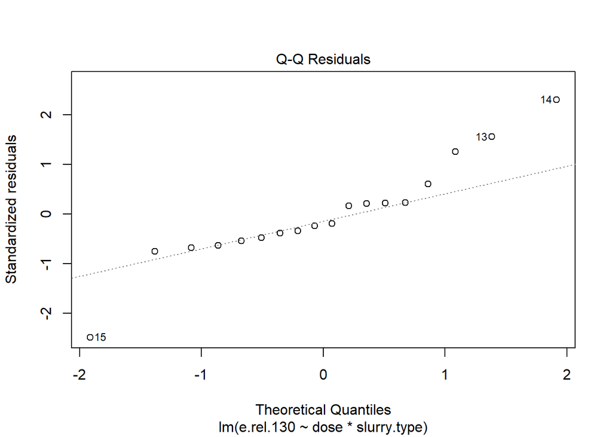

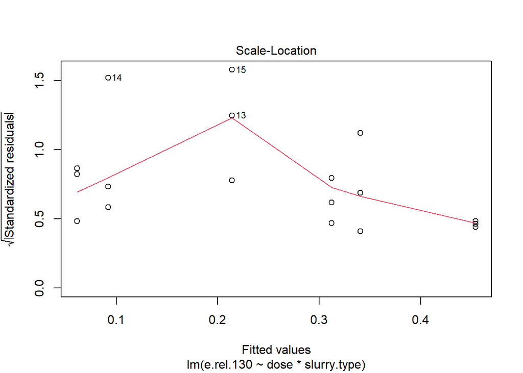

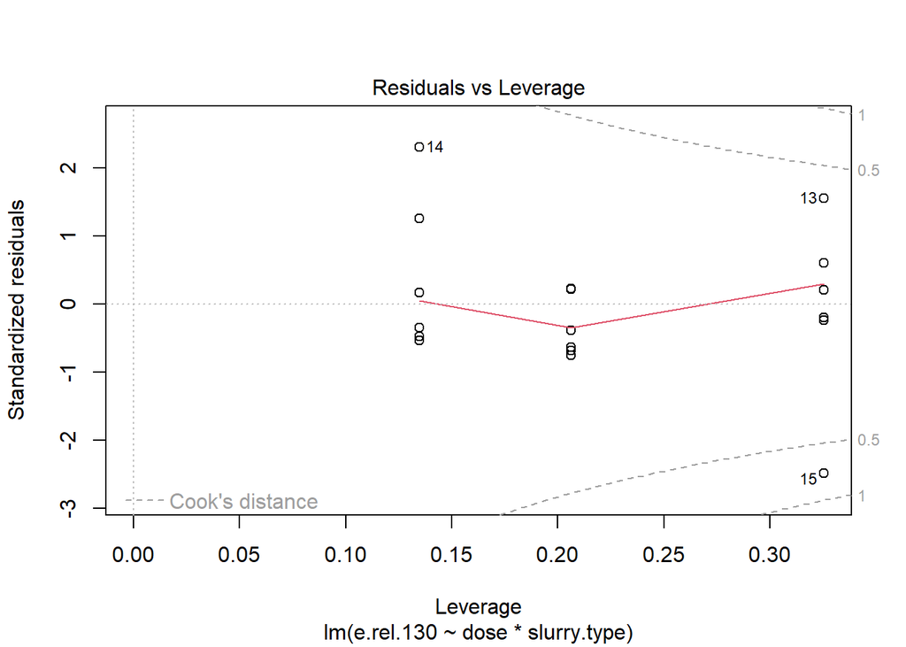

```r
plot(modb, ask = FALSE)
```

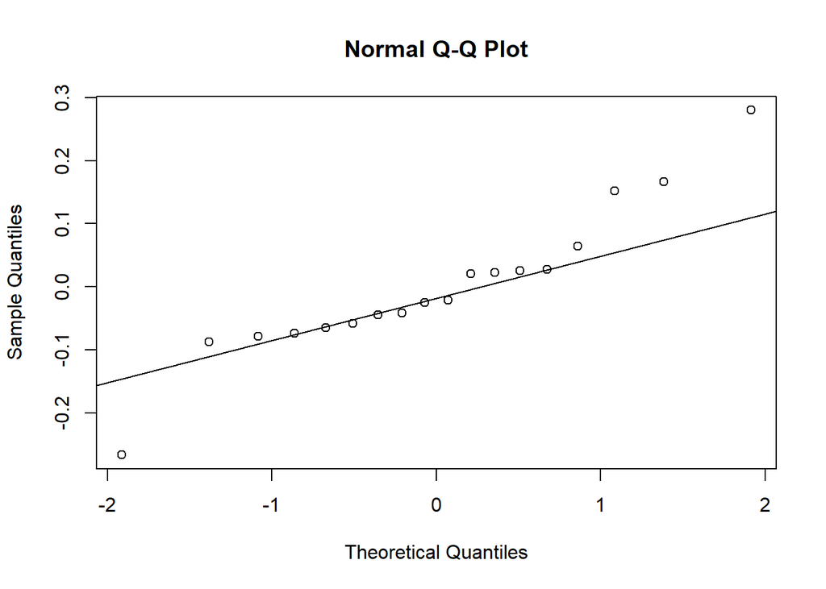

```r
qqnorm(resid(modb))
qqline(resid(modb))
```

```r
confint(modb)
```

```
##                         2.5 %      97.5 %
## (Intercept)         0.1851420  0.43952467
## dose               -0.7435708  3.57690412
## slurry.typePS      -0.4308090 -0.07105762
## dose:slurry.typePS -2.9450371  3.16503711
```

# Separate test for digestate

Digestate has lower variability. Test separately liquid pig and liquid digestate.

```r
bsumm.pig <- bsumm[trial %in% paste('Trial', 9), ]
modb2 <- lm(e.rel.130 ~ dose, data = bsumm.pig)
summary(modb2)
```

```
##
## Call:
## lm(formula = e.rel.130 ~ dose, data = bsumm.pig)
##
## Residuals:
##      Min       1Q   Median       3Q      Max
## -0.26657 -0.07900 -0.04153  0.06493  0.28007
##
## Coefficients:
##             Estimate Std. Error t value Pr(>|t|)
## (Intercept)  0.06140    0.07718   0.796    0.452
## dose         1.52667    1.31080   1.165    0.282
##
## Residual standard error: 0.1699 on 7 degrees of freedom
## Multiple R-squared:  0.1623, Adjusted R-squared:  0.04266
## F-statistic: 1.356 on 1 and 7 DF,  p-value: 0.2823
```

```r
anova(modb2)
```

|  | Df | Sum Sq | Mean Sq | F value | Pr(>F) |
| --- | --- | --- | --- | --- | --- |
| dose | 1 | 0.03915595 | 0.03915595 | 1.356489 | 0.282299 |
| Residuals | 7 | 0.20205957 | 0.02886565 | NA | NA |

No effect of biochar dose on liquid pig slurry.

```r
bsumm.ad <- bsumm[trial %in% paste('Trial', 8), ]
modb3 <- lm(e.rel.130 ~ dose, data = bsumm.ad)
summary(modb3)
```

```
##
## Call:
## lm(formula = e.rel.130 ~ dose, data = bsumm.ad)
##
## Residuals:
##      Min       1Q   Median       3Q      Max
## -0.07333 -0.04433 -0.02100  0.02300  0.15233
##
## Coefficients:
##             Estimate Std. Error t value Pr(>|t|)
## (Intercept)  0.31233    0.03282   9.516 2.96e-05 ***
## dose         1.41667    0.55743   2.541   0.0386 *
## ---
## Signif. codes:  0 '***' 0.001 '**' 0.01 '*' 0.05 '.' 0.1 ' ' 1
##
## Residual standard error: 0.07225 on 7 degrees of freedom
## Multiple R-squared:  0.4799, Adjusted R-squared:  0.4056
## F-statistic: 6.459 on 1 and 7 DF,  p-value: 0.03858
```

```r
anova(modb3)
```

|  | Df | Sum Sq | Mean Sq | F value | Pr(>F) |
| --- | --- | --- | --- | --- | --- |
| dose | 1 | 0.03371667 | 0.03371667 | 6.458896 | 0.03858303 |
| Residuals | 7 | 0.03654133 | 0.00522019 | NA | NA |

There is an effect of biochar dose on liquid digestate

Conclusions *For the liquid fraction of digestate, the addition of an increasing dose of biochar had an effect on emissions* An increasing dose of biochar increased the emissions from the liquid fraction of digestate *An increasing dose of biochar to the liquid fraction of pig slurry did not have an effect on emissions

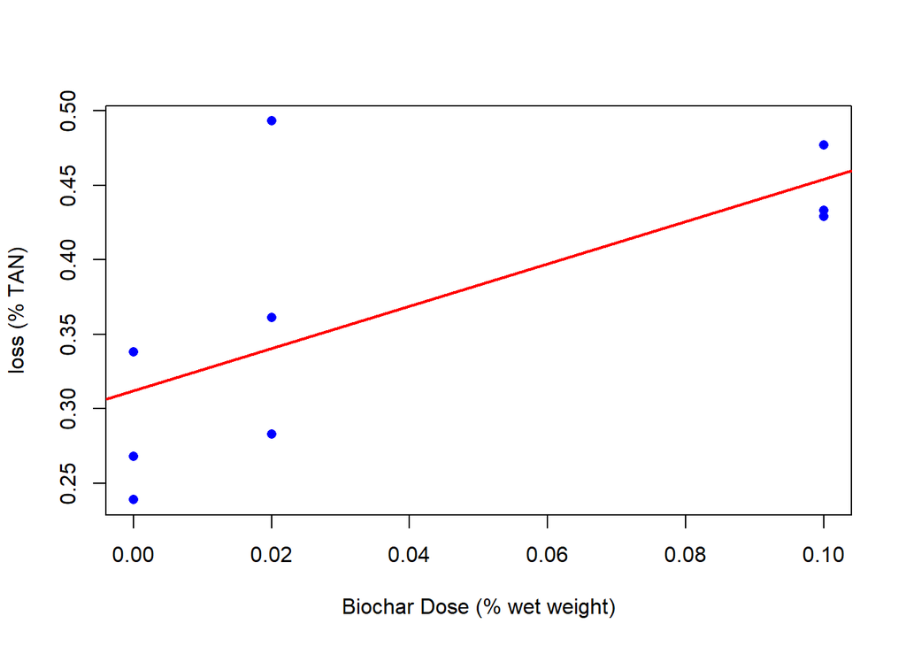

```r
# Plot
plot(bsumm.ad$dose, bsumm.ad$e.rel.130,
     xlab = "Biochar Dose (% wet weight)",
     ylab = "loss (% TAN)",
     main = "",
     pch = 16,
     col = "blue",
     cex = 1)

# Add regression line
abline(modb3, col = "red", lwd = 2)
```

For trial 7, we want to test if the biochar addition to the solid fraction of digestate had an effect on emissions. (in this case we only have no biochar and 1 does of biochar (0 vs 10% on wet weight) so the dose has been considered as a factor)

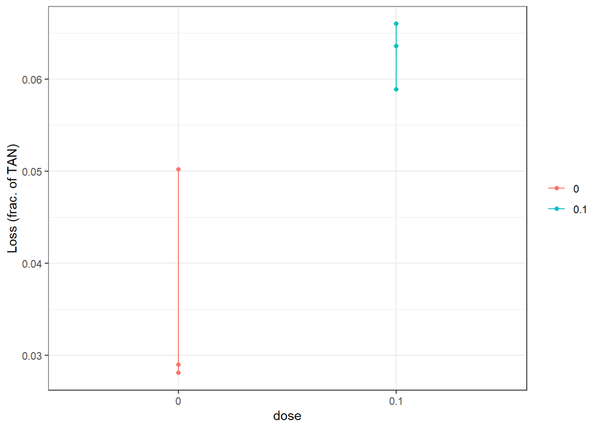

```r
ggplot(bsumm.solid, aes(dose, e.rel.130, color =dose )) +
  geom_point() +
  geom_line(aes(group = dose)) +
  theme_bw() +
  labs(y = 'Loss (frac. of TAN)') +
  theme(legend.title = element_blank())
```

from this plot it looks like biochar addition caused higher emissions compared to non-addition

Fit the linear model to test if the emissions are influenced by biochar addition

```r
modb4 <- lm(e.rel.130 ~ dose, data = bsumm.solid)
summary(modb4)
```

```
##
## Call:
## lm(formula = e.rel.130 ~ dose, data = bsumm.solid)
##
## Residuals:
##          1          2          3          4          5          6
## -0.0039333  0.0144333 -0.0076667  0.0031667 -0.0067667  0.0007667
##
## Coefficients:
##             Estimate Std. Error t value Pr(>|t|)
## (Intercept) 0.035767   0.005315   6.730  0.00254 **
## dose0.1     0.027067   0.007516   3.601  0.02274 *
## ---
## Signif. codes:  0 '***' 0.001 '**' 0.01 '*' 0.05 '.' 0.1 ' ' 1
##
## Residual standard error: 0.009206 on 4 degrees of freedom
## Multiple R-squared:  0.7643, Adjusted R-squared:  0.7053
## F-statistic: 12.97 on 1 and 4 DF,  p-value: 0.02274
```

#Conclusions *Addition of biochar to the solid fraction of separated digestate had an effect on emissions* Solid fraction of digestate with biochar addition had higher emissions compared to solid fraction of digestate without biochar addition